### Data Introduction

This data was acquired form FishBase (Froese and Pauley 2000) using the rfishbase package (Boettiger et al., 2012; see data_acquisition.R for data retrieval).

The data set includes the following variables:

- `species`: the scientific name of fish
- `genus`: the scientific genus of fish
- `common_name`: common name used for fish
- `body_shape`**: shape of fish body (elongated, fusiform/normal, eel-like, short and/or deep, other)**
- `habitat`**: area of the ocean that fish typically resides in**
- `depth_range_shallow`**: minimum depth fish is found**
- `depth_range_deep`**: maximum depth fish is found**
- `vulnerability`**: metric for how at risk a fish is to over fishing based on other life history and ecological traits**
- `length`**: total length, fork length, or standard length of fish**
- `trophic_level`**: trophic level that the fish occupies based on position in food web**
- `food_troph`: trophic level that fish’s food source occupies
- `food`**: type of food source fish consumes**
- `family`: the scientific family of fish

*Bold variables are included in the models. A full copy of the codebook is included in the data/raw folder*

#### Habitat Types

This project attempts to predict 8 different habitat types. These habitats are described below to note differences.

1. pelagic: living within several regions of the pelagic zone, through both shallower pelagic-oceanic and deeper bathypelagic
2. pelagic-neritic: relating to upper layers of the ocean on the continental shelf. Waters here are not as deep as the pelagic zone
3. reef-associated: living in association with a coral reef. This habitat is the most diverse, offering an array of food types and shelters
4. demersal: relating to living on or near the ocean floor, whether in the pelagic-neritic, pelagic, or bathypelagic zones
5. benthopelagic: relating specifically to the ocean floor in the pelagic zone, but not at the deepest depths
6. bathydemersal: relating to the ocean floor at depths greater than 200 meters
7. pelagic-oceanic: relating specifically to the upper layers of the open ocean. Food is scarce
8. bathypelagic: relating to deeper layers of the open ocean at the continental slope. Limited sunlight reaches this zone

While there is some possible overlap in these categories, they are kept separate as specifically defined in FishBase. Data has already been pre-processed for you.

#### Data Cleaning

We are going to load the data and only use two categories (demersal - i.e., bottom dwelling species - and reef-associated).

Additionally, we are going to binary encode these values. This means turning them into a 0 and 1.

```r
fish_clean = read_csv(here("data", "fish_clean.csv")) %>%
  filter(habitat == "demersal" | habitat == "reef-associated") %>%
  mutate(habitat = case_when(
    habitat == "demersal" ~ 0,
    habitat == "reef-associated" ~ 1,
  ))
```

### Exploratory Data Analysis

Now I will look at the distribution of variables that did not have missing values, look at correlations between variables, and visualize the relationship between predictor variables and habitat type.

##### Habitat Counts

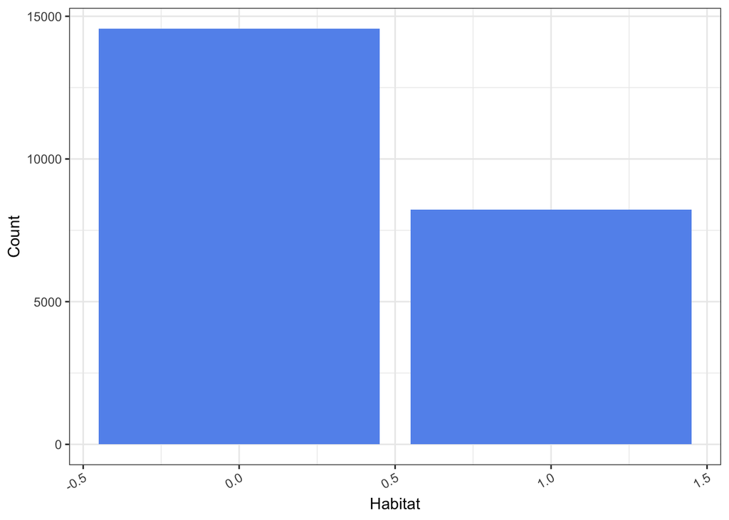

Figure 10. counts of each habitat type represented in the fish dataset

```r
ggplot(fish_clean, aes(habitat)) + #order by count
  geom_bar(fill = "cornflowerblue") + #get counts
  theme_bw() + #bw theme
  labs(x = "Habitat",
       y = "Count") + #change labels
  theme(axis.text.x = element_text(angle = 30, hjust=1)) #rotate x axis labels
```

#### Correlations

Next, I will look at the correlation between numerical predictor values used in the model.

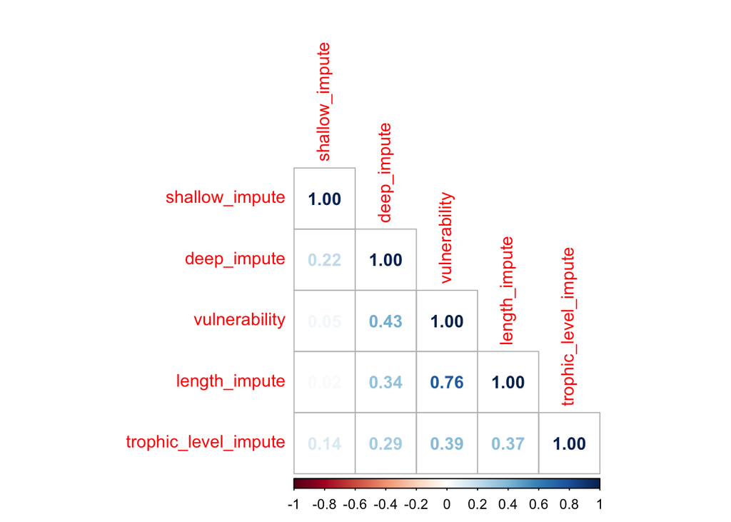

Figure 11. numerical correlations between continous predictor variables

```r
fish_clean %>%
  dplyr::select(shallow_impute, deep_impute, vulnerability, length_impute, trophic_level_impute) %>%  #get numeric columns
  cor() %>% #calcuate correlations
  corrplot(type = 'lower', diag = TRUE,
           method = 'number') #plot correlations
```

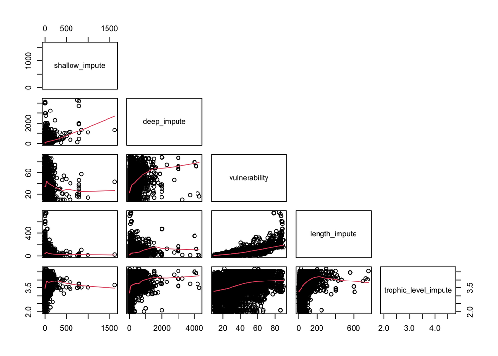

Figure 12. scatter plots representing relationships between predictor variables

```r
fish_clean %>%
  dplyr::select(shallow_impute, deep_impute, vulnerability, length_impute, trophic_level_impute) %>%  #get numeric columns
  pairs(upper.panel = NULL,
        lower.panel = panel.smooth) #use pairs to plot scatter plots of variable swith smoothed regression lines
```

### Modeling

Today, we will look at preforming linear regression on this data set. We will continue to come back to this data set as we learn more models in this section.

#### Training and Testing Data Creation

Here, we will use functions from the `rsample` package within `TidyModels`

```r
data_split <- initial_split(fish_clean, prop = 0.8, strata = habitat)

train <- training(data_split)
test <- testing(data_split)

head(train)
```

```
## # A tibble: 6 × 11
##   genus  species habitat vulnerability family trophic_level_impute length_impute
##   <chr>  <chr>     <dbl>         <dbl> <chr>                 <dbl>         <dbl>
## 1 Abali… Abalis…       0          43.8 Balis…                 3.64         60
## 2 Abali… Abalis…       0          43.8 Balis…                 3.64         60
## 3 Acant… Acanth…       0          34.5 Monac…                 2.09         35
## 4 Acant… Acanth…       0          21.2 Monac…                 2.09         14
## 5 Acant… Acanth…       0          10   Chaen…                 3.43          3.20
## 6 Acant… Acanth…       0          10   Chaen…                 3.43          5.10
## # ℹ 4 more variables: shallow_impute <dbl>, deep_impute <dbl>,
## #   shape_impute <chr>, food_impute <chr>
```

```r
head(test)
```

```
## # A tibble: 6 × 11
##   genus  species habitat vulnerability family trophic_level_impute length_impute
##   <chr>  <chr>     <dbl>         <dbl> <chr>                 <dbl>         <dbl>
## 1 Abude… Abudef…       1          28.2 Pomac…                 3.15         17
## 2 Abude… Abudef…       1          35.8 Pomac…                 3.10         30
## 3 Abude… Abudef…       1          32.5 Pomac…                 2.80         16
## 4 Acant… Acanth…       1          50.4 Monac…                 2.09         55
## 5 Acant… Acanth…       1          10   Chaen…                 3.43          1.80
## 6 Acant… Acanth…       1          10   Chaen…                 3.43          4.30
## # ℹ 4 more variables: shallow_impute <dbl>, deep_impute <dbl>,
## #   shape_impute <chr>, food_impute <chr>
```

#### Recipe Creation

After splitting my data, the first step is to create a recipe indicating the formula for the model and any pre-processing steps I want to preform on my data. Here we will use the `recipes` package.

I will be predicted habitat based on trophic level, length, minimum depth, maximum depth, vulnerability, body shape, and food source type. We will be normalizing all numeric predictors

```r
fish_recipe <- recipe(habitat ~ shape_impute + food_impute + shallow_impute + deep_impute + vulnerability + length_impute + trophic_level_impute, data = train) %>% # Create model recipe
  step_normalize(all_numeric_predictors()) # Normalize all numeric predictors
```

#### Model 1: Linear Regression

The model specifications in `TidyModels` are within the `parsnip` package

```r
lm_model <- linear_reg() %>%
  set_engine("lm") %>% # Set engine as "lm" from base R
  set_mode("regression")
```

After specifiying the model, we can create a workflow from the `workflows` package

```r
lm_workflow <- workflow() %>% # Create workflow
  add_model(lm_model) %>%
  add_recipe(fish_recipe)

lm_workflow
```

```
## ══ Workflow ════════════════════════════════════════════════════════════════════
## Preprocessor: Recipe
## Model: linear_reg()
##
## ── Preprocessor ────────────────────────────────────────────────────────────────
## 1 Recipe Step
##
## • step_normalize()
##
## ── Model ───────────────────────────────────────────────────────────────────────
## Linear Regression Model Specification (regression)
##
## Computational engine: lm
```

#### Model Fitting

Now we will “fit” the model, again using `parsnip`.

```r
train_fit <- fit(lm_workflow, train) # Fit the model to the training set

train_fit
```

```
## ══ Workflow [trained] ══════════════════════════════════════════════════════════
## Preprocessor: Recipe
## Model: linear_reg()
##
## ── Preprocessor ────────────────────────────────────────────────────────────────
## 1 Recipe Step
##
## • step_normalize()
##
## ── Model ───────────────────────────────────────────────────────────────────────
##
## Call:
## stats::lm(formula = ..y ~ ., data = data)
##
## Coefficients:
##                     (Intercept)            shape_imputeelongated
##                         0.14640                         -0.02789
##   shape_imputefusiform / normal                shape_imputeother
##                         0.12048                         -0.08616
## shape_imputeshort and / or deep                food_imputenekton
##                         0.11156                          0.15820
##               food_imputeothers                food_imputeplants
##                        -0.05319                          0.20954
##           food_imputezoobenthos           food_imputezooplankton
##                         0.13621                          0.17699
##                  shallow_impute                      deep_impute
##                        -0.03397                         -0.05972
##                   vulnerability                    length_impute
##                        -0.10183                          0.05658
##            trophic_level_impute
##                         0.01583
```

```r
train_predict <- predict(object = train_fit, new_data = train)  %>% # Predict the training set
  bind_cols(train) # Bind training set column to prediction
```

```r
test_predict <- predict(train_fit, test) %>%  # Predict the testing set
  bind_cols(test) # Bind testing set column to prediction

head(test_predict)
```

```
## # A tibble: 6 × 12
##   .pred genus          species habitat vulnerability family trophic_level_impute
##   <dbl> <chr>          <chr>     <dbl>         <dbl> <chr>                 <dbl>
## 1 0.478 Abudefduf      Abudef…       1          28.2 Pomac…                 3.15
## 2 0.475 Abudefduf      Abudef…       1          35.8 Pomac…                 3.10
## 3 0.477 Abudefduf      Abudef…       1          32.5 Pomac…                 2.80
## 4 0.394 Acanthaluteres Acanth…       1          50.4 Monac…                 2.09
## 5 0.428 Acanthemblema… Acanth…       1          10   Chaen…                 3.43
## 6 0.427 Acanthemblema… Acanth…       1          10   Chaen…                 3.43
## # ℹ 5 more variables: length_impute <dbl>, shallow_impute <dbl>,
## #   deep_impute <dbl>, shape_impute <chr>, food_impute <chr>
```

#### Model Metrics and Evaluation

Finally, we will calulate some metrics for preformance, using the `yardstick` package.

```r
train_metrics <- train_predict %>%
  metrics(habitat, .pred)
train_metrics
```

```
## # A tibble: 3 × 3
##   .metric .estimator .estimate
##   <chr>   <chr>          <dbl>
## 1 rmse    standard      0.456
## 2 rsq     standard      0.0993
## 3 mae     standard      0.422
```

```r
test_metrics <- test_predict %>%
  metrics(habitat, .pred)
test_metrics
```

```
## # A tibble: 3 × 3
##   .metric .estimator .estimate
##   <chr>   <chr>          <dbl>
## 1 rmse    standard       0.455
## 2 rsq     standard       0.105
## 3 mae     standard       0.421
```

### Future

Eventually, we will use some other key packages in tidy models such as `dials` and `tune`